# Phylogenetic Analysis of Hantavirus Andes MV Hondius Cruise Outbreak in April - May 2026

Published

May 25, 2026

# Introduction

Both WHO AND ECDC has been notified regarding a potential outbreak starting in April on MV Hondius cruise, that departed from South America and was on its way towards Europe on the Atlantic Ocean. Patient zero, died onboard ship on 11.04. Two additional deaths have occurred, including wife of patient zero and a German woman. Currently, 6 cases have been laboratory confirmed as Hantavirus andes infection, the only species within Orthohantavirus genus with previous evidence of ability to human - human transmission. One of the passengers, British national has been evacuated to South Africa in critical condition and on 2.05 PCR test for Hantavirus of his sample result came positive, pointing to potential outbreak. This mobilized South African authorities to test the wife of index patient body. The test also returned positive and on 4.05 WHO declared an outbreak. As of 13.05, all patients have been removed from the ship and repatriated. The current status is 8 confirmed cases, two possible, 1 inconclusive and 3 deaths [1-4].

After just 6 days upon first PCR result and 4 days after declaring an outbreak, first sequence has been publicaly released, from a Swiss resident that traveled the MV Hondius cruise [5]. So far, sequences of 5 isolates have been released and apart from Swiss isolate also include sequences from South African (n = 2) and Netherlands (n = 2) [6].

# Phylogenetic placement across Orthohantavirus taxa

## Methods

First, to assess identity taxonomy of the Hantavirus isolates, phylogenetic placement was performed within broad variety of Orthohantavirus species, including members of old world Hantaviruses (Murinae such as Seoul virus, Arvicolinae such as Puumala virus). Strains were selected based on list specified charactarized previously by Jonsson et al [7]. The taxonomy was verified with virological taxonomy [8]. In the species specified in table 1 of [7], did not match ICTV classifical. For example some of the species such as Calabazo, there was no official ICTV classfication. Further, several species have been reclassfied. For instance, Rio Segundo virus taxa has been abolished after 2015. Also, some of the species were merged into single taxonomy, such as Bermejo virus, Pergamino virus, Lechiguanas virus, Maciel virus, Oran virus, Laguna Negra virus, Araraquara virus, Juquitiba virus which are all members of Ortohantavirus andense taxa. Selecion of strains was guided by self-determining rules: include representatives of both Old and New World Hantavirus taxa, strains with complete M segment sequence in Genbank category of NCBI virus were selected. If there was more than 1 sequence available for species, 2 sequences were selected, from different geographical locations, if possbible. For Orthohantavirus andes, 3 sequences were retrieved, one being an oubtreak strain. Upon selection, sequences were retried from NCBI virus in multi fasta format, as well as corresponding metadata in csv format. Sequences were aligned using MAFFT v7.526 [9] with –auto flag. Phylogenetic tree was inferred with IQTREE v3.1.1 [10] with multiple sequence alignment as input, while specifying -m MFP for sequence evolution model finding and -B 10000 for number of ultrafast bootrastraps. Phylogenetic tree was then visualized in R (Figure 1).

## Result

The outbreak strain have been placed within Orthohantavirus andes species, with high clade bootstrap support value (97%) Figure 1, supporting the initial findings regarding the species of outbreak isolate [5].

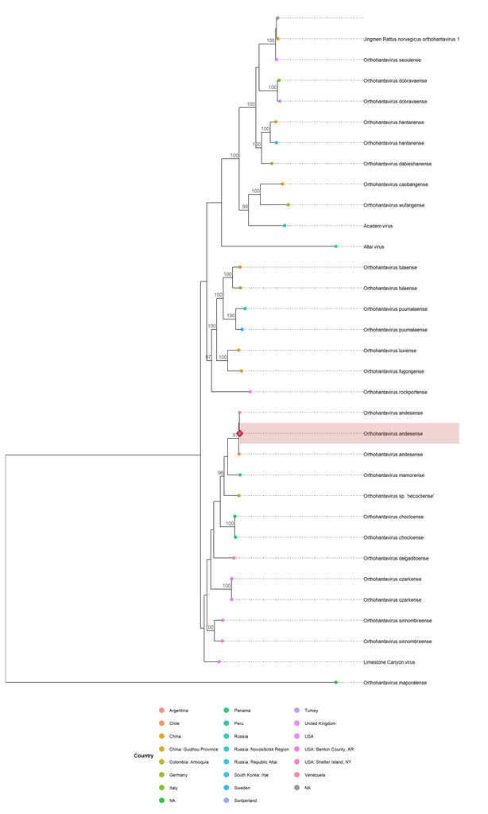

Figure 1: Phylogenetic placement of Outbreak Strain Within Hantavirus Taxonomy

# Phylogenetic placement within Orthohantavirus andense phylogeny

## Methods

For phylogenetic analysis at the Orthohantavirus andes species level, sequences were retrieved from pathoplexus portal [6], for segment S, M and L. Sequences were filtered based on the known length range of each segment according to [11]. To account for variation, introduced during sequencing we allowed variation of +- 200 bp for each of the segmenty, which resulted in following length filtering criteria: S - 1.6-2.3 kb, M - 3.5-4 kb, L - 6.3-6.8 kb. Ultimately, 102, 87 and 76 sequences were obtained for segment S, M and L, respectively (accessed on 15.05.2026), in a raw multi fasta format. The sequences were aligned with MAFFT [9], with –maxiterate 1000 and –localpair parameters, followed by manual trimming in MEGA12 [12], to remove uneven 5’ and 3’ ends as well as grouped sites that have gaps in most of the sequences. PP_006W1UB.1 sequence was removed from M segment alignment due to significant amount of unknown nucleotides (N). After trimming, phylogenetic reconstruction was performed with IQTREE3 (10) for each segment alignment, with GTR+F+R2 sequence evolutionary model (best fit model, estimated by model finder), with 10000 ultrabootstraps. Phylogenetic trees were visualized in R.

## Results

The placement with sister clade is consistent across S, M, L segments Figure 2, Figure 3, Figure 4, Figure 5, supporting no evidence of recombination, between different strains of Orthohantavirus andes. Outbreak samples (n = 5) form a monophylethic clade consisting of highly similar sequences, supporting possibility of single spillover event or multiple spillovers over short period of time (infection from common source). The most closely related sequences are: PP_006VZ4W.1 and PP_006VZ5U.1 , which correspond to NRC-3/18 and NRC-4/18, two cases from San Martin de Los (Andes, Neuquen, Argentina, near border with Chile) from 2018. San Martin de Los is located approximately by 2350 km road distance from Ushuaia, a location where cruise departed from, and even further from the islands where cruise stopped and where spillover also could potentially occur. Currently, there are no sequences, either from rodent or human Hantavirus andes isolates from southern Chile, Argentina or the islands where cruise stopped.  
This highlights limited knowledge of Hantavirus andes phylogeography and therefore limited ability to answer the question of spatial origin of spillover, with currently available data.

**Segment S**

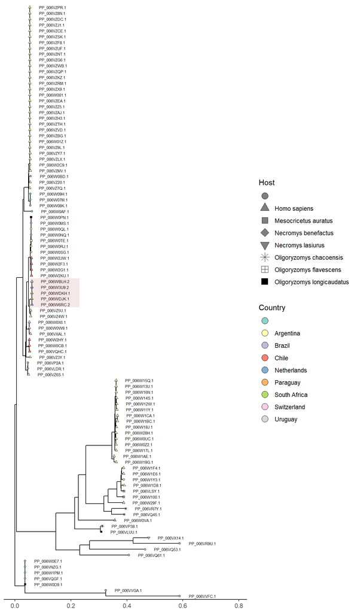

Figure 2: Phylogenetic placement of outbreak strains within Orthohantavirus andes, segment S

**Segment M**

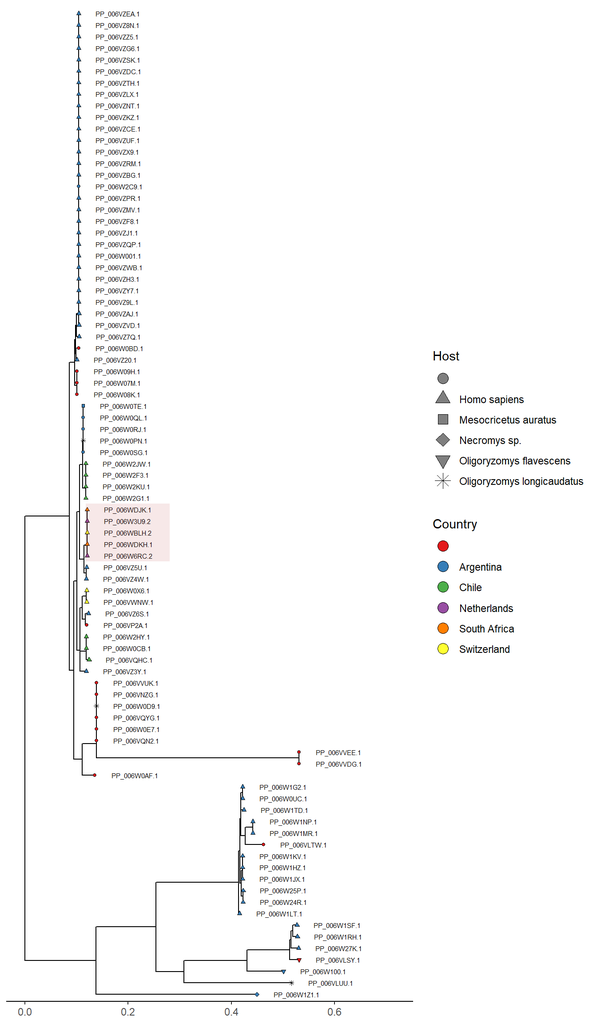

Figure 3: Phylogenetic placement of outbreak strains within Orthohantavirus andes, segment M

**Segment L**

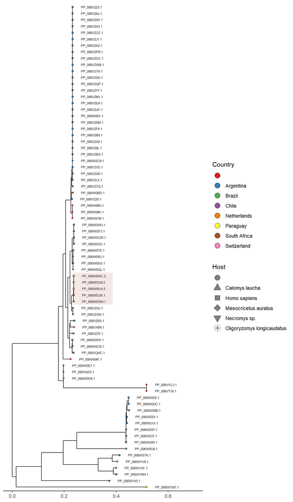

Figure 4: Phylogenetic placement of outbreak strains within Orthohantavirus andes, segment L

**Consistency of placement across various placements**

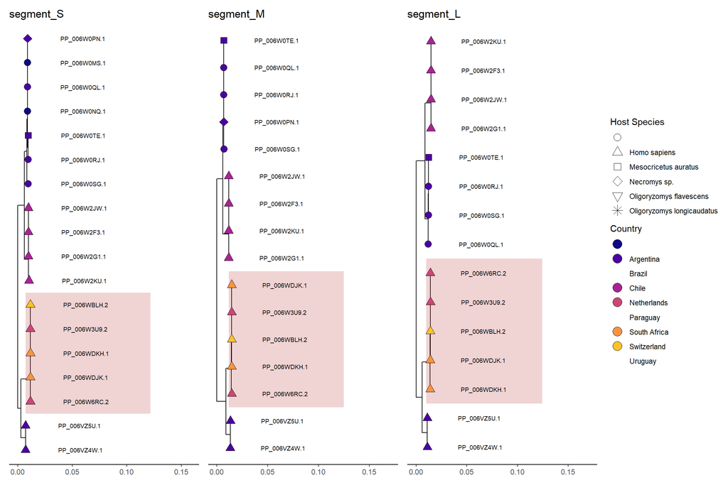

Figure 5: Consistency of phylogenetic placement within Ortohantavirus andes, across segments

# SNP distance

## Methods

The trimmed alignment for each of the segments was used to derive pairwise SNP distances between all outbreak samples and sister clade samples. SNP distances were obtained with dist.dna function (R, package: ape). Networks were generated with graph_from_data_frame function (R, package: igraph).

## Results

**S**

Table 1: SNP distance between outbreak and sister clade samples: S segment

SNP distance between outbreak and sister clade samples: S segment

|  | PP_006W6RC.2 | PP_006W3U9.2 | PP_006WBLH.2 | PP_006WDJK.1 | PP_006WDKH.1 | PP_006VZ5U.1 | PP_006VZ4W.1 |
| --- | --- | --- | --- | --- | --- | --- | --- |
| PP_006W6RC.2 | 0 | 0 | 0 | 0 | 0 | 22 | 22 |
| PP_006W3U9.2 | 0 | 0 | 0 | 0 | 0 | 22 | 22 |
| PP_006WBLH.2 | 0 | 0 | 0 | 0 | 0 | 22 | 22 |
| PP_006WDJK.1 | 0 | 0 | 0 | 0 | 0 | 22 | 22 |
| PP_006WDKH.1 | 0 | 0 | 0 | 0 | 0 | 22 | 22 |
| PP_006VZ5U.1 | 22 | 22 | 22 | 22 | 22 | 0 | 0 |
| PP_006VZ4W.1 | 22 | 22 | 22 | 22 | 22 | 0 | 0 |

SNP distance between outbreak and sister clade strains - segment S

**M**

Table 2: SNP distance between outbreak and sister clade samples: M segment

SNP distance between outbreak and sister clade samples: M segment

|  | PP_006W6RC.2 | PP_006W3U9.2 | PP_006WBLH.2 | PP_006WDJK.1 | PP_006WDKH.1 | PP_006VZ5U.1 | PP_006VZ4W.1 |
| --- | --- | --- | --- | --- | --- | --- | --- |
| PP_006W6RC.2 | 0 | 2 | 2 | 2 | 2 | 36 | 35 |
| PP_006W3U9.2 | 2 | 0 | 0 | 0 | 0 | 36 | 35 |
| PP_006WBLH.2 | 2 | 0 | 0 | 0 | 0 | 36 | 35 |
| PP_006WDJK.1 | 2 | 0 | 0 | 0 | 0 | 36 | 35 |
| PP_006WDKH.1 | 2 | 0 | 0 | 0 | 0 | 36 | 35 |
| PP_006VZ5U.1 | 36 | 36 | 36 | 36 | 36 | 0 | 1 |
| PP_006VZ4W.1 | 35 | 35 | 35 | 35 | 35 | 1 | 0 |

SNP distance between outbreak and sister clade strains - segment M

**L**

Table 3: SNP distance between outbreak and sister clade samples: L segment

SNP distance between outbreak and sister clade samples: L segment

|  | PP_006W6RC.2 | PP_006W3U9.2 | PP_006WBLH.2 | PP_006WDJK.1 | PP_006WDKH.1 | PP_006VZ5U.1 | PP_006VZ4W.1 |
| --- | --- | --- | --- | --- | --- | --- | --- |
| PP_006W6RC.2 | 0 | 1 | 0 | 0 | 1 | 73 | 73 |
| PP_006W3U9.2 | 1 | 0 | 1 | 1 | 2 | 79 | 79 |
| PP_006WBLH.2 | 0 | 1 | 0 | 0 | 1 | 80 | 80 |
| PP_006WDJK.1 | 0 | 1 | 0 | 0 | 1 | 80 | 80 |
| PP_006WDKH.1 | 1 | 2 | 1 | 1 | 0 | 80 | 80 |
| PP_006VZ5U.1 | 73 | 79 | 80 | 80 | 80 | 0 | 0 |
| PP_006VZ4W.1 | 73 | 79 | 80 | 80 | 80 | 0 | 0 |

SNP distance between outbreak and sister clade strains - segment L

**SNP distance network of outbreak strain - S segment**

```
             PP_006W6RC.2 PP_006W3U9.2 PP_006WBLH.2 PP_006WDJK.1 PP_006WDKH.1
PP_006W6RC.2            0            0            0            0            0
PP_006W3U9.2            0            0            0            0            0
PP_006WBLH.2            0            0            0            0            0
PP_006WDJK.1            0            0            0            0            0
PP_006WDKH.1            0            0            0            0            0
```

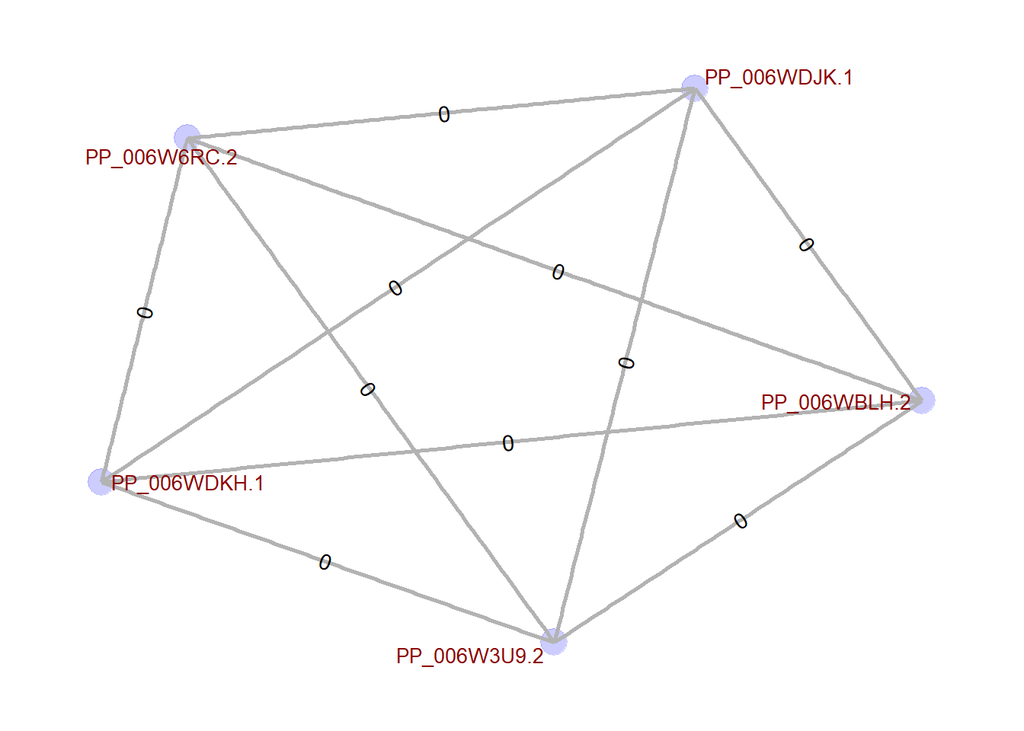

Relatedness network of outbreak strains based on SNP distances, segment S

**SNP distance network of outbreak strain - M segment**

```
             PP_006W6RC.2 PP_006W3U9.2 PP_006WBLH.2 PP_006WDJK.1 PP_006WDKH.1
PP_006W6RC.2            0            2            2            2            2
PP_006W3U9.2            2            0            0            0            0
PP_006WBLH.2            2            0            0            0            0
PP_006WDJK.1            2            0            0            0            0
PP_006WDKH.1            2            0            0            0            0
```

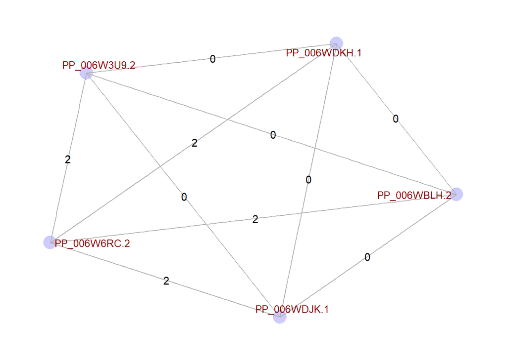

Relatedness network of outbreak strains based on SNP distances, segment M

**SNP distance network of outbreak strain - L segment**

```
             PP_006W6RC.2 PP_006W3U9.2 PP_006WBLH.2 PP_006WDJK.1 PP_006WDKH.1
PP_006W6RC.2            0            1            0            0            1
PP_006W3U9.2            1            0            1            1            2
PP_006WBLH.2            0            1            0            0            1
PP_006WDJK.1            0            1            0            0            1
PP_006WDKH.1            1            2            1            1            0
```

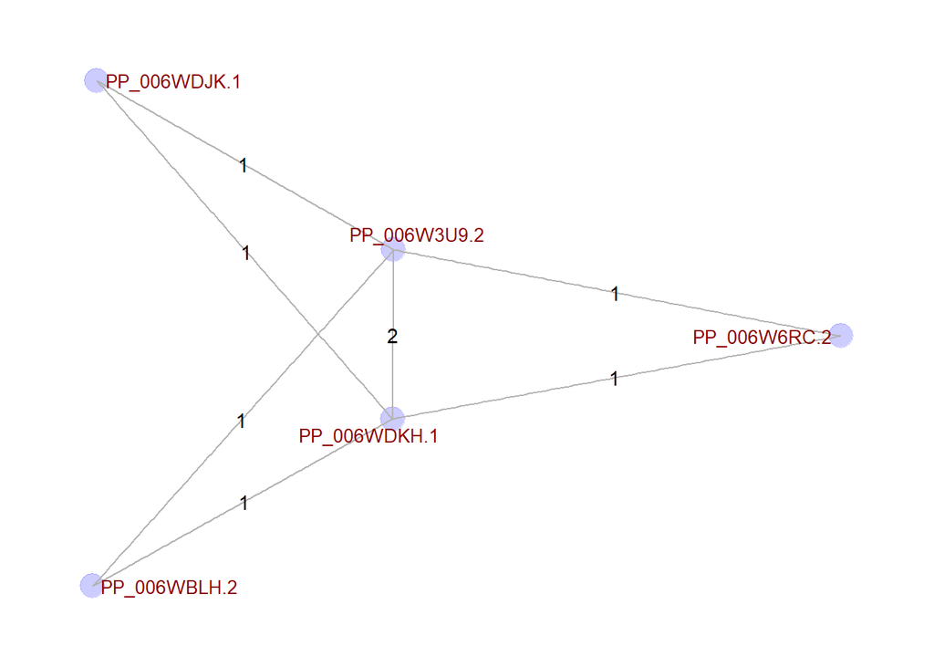

Relatedness network of outbreak strains based on SNP distances, segment L

# Molecular clock analysis

## Methods

For molecular dating, sequences were re-downloaded from pathoplexus [6], including only ones having collection date available between 1995-01-01 and 2026-05-06, within length range: S - 1.6-2.3 kb, M - 3.5-4 kb, L - 6.3-6.8 kb. 38, 30 and 27 sequences were obtained for segment S, M and L, respectively. Sequences were aligned with mafft [9], specifying –maxiterate 1000 and –localpair parameters and the alignments were manually trimmed in MEGA12 [12] to remove 5’ and 3’ ragged ends. Blocks of missing sites within sequence alignment were removed. Sites with missing gaps for most or all sequences in alignment were also removed. Sequences PP 006W1TD.1|M, PP 006W1UB.1|M and PP_006W6RC.2|L were removed due to abudance of unknown base calls (Ns). Phylogenies were reconstructed using IQTREE3 [10], with -B 10000 and -m MFP. Tip dating was performed with treetime [13], specifying following parameters: –confidence, –max-iter 100, –reroot least-squares –gtr infer. We run time calibration multiple times with different parameters specified for different clock models (–relax 1.0 0 for uncorrelated relaxed clock, –relax 1.0 1.0 for correlated relaxed clock and no flag specified for strict clock) and coalescence models (–coalescent opt for costant, –coalescent skyline for skyline or no parameter specified). We estimated lower and upper bounds of tMRCA for the outbreak strains.

## Results

**Temporal Signal Assessment - S segment**

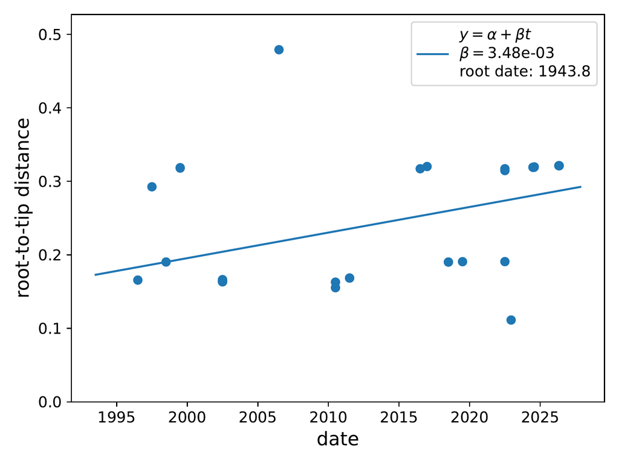

Figure 6: Root to tip regresssion analysis results for Segment S

**Temporal Signal Assessment - M segment**

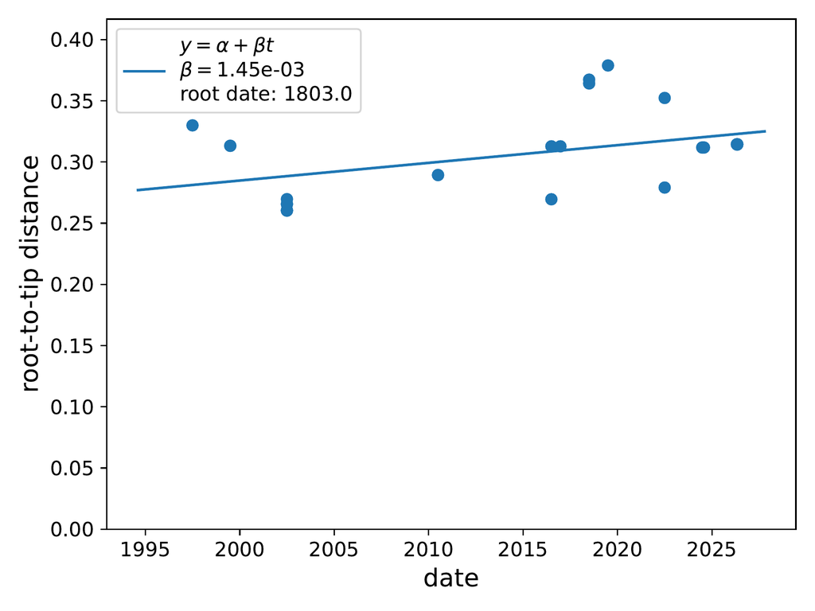

Figure 7: Root to tip regression analysis results for segment M

**Temporal Signal Assessment - L segment**

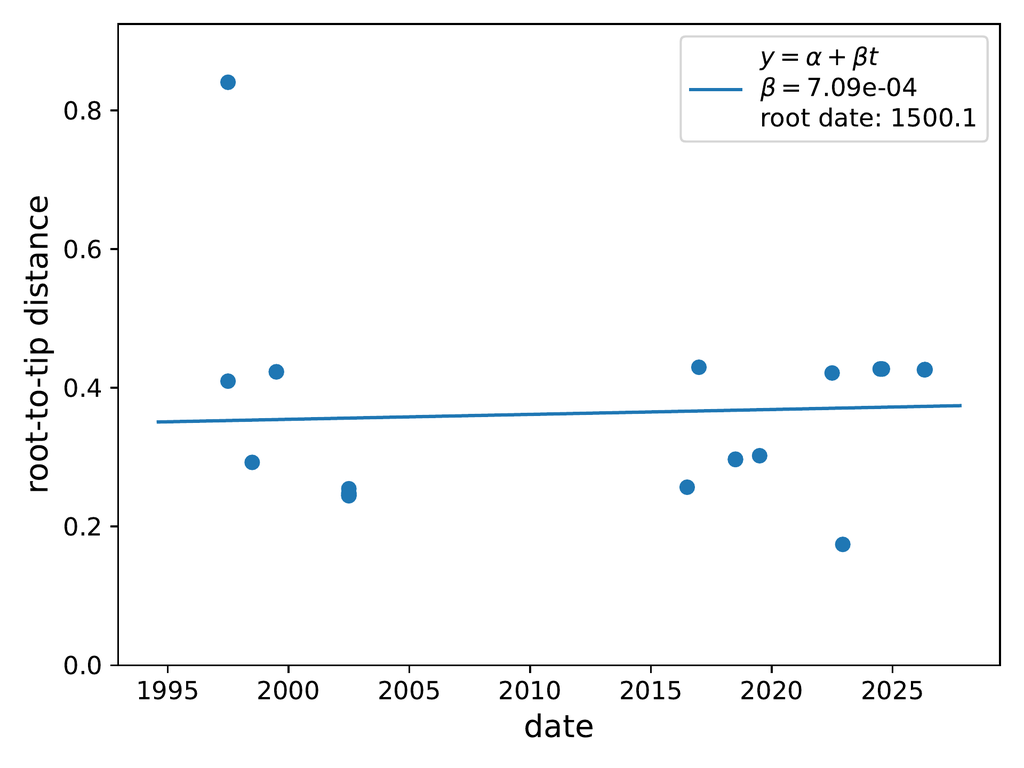

Figure 8: Root to tip regression analysis results for segment L

**Molecular clock estimates**

Table 4: Evolutionary rate estimates for each segment

[output not shown]

**Time calibrated phylogeny and tMRCA - segment S**

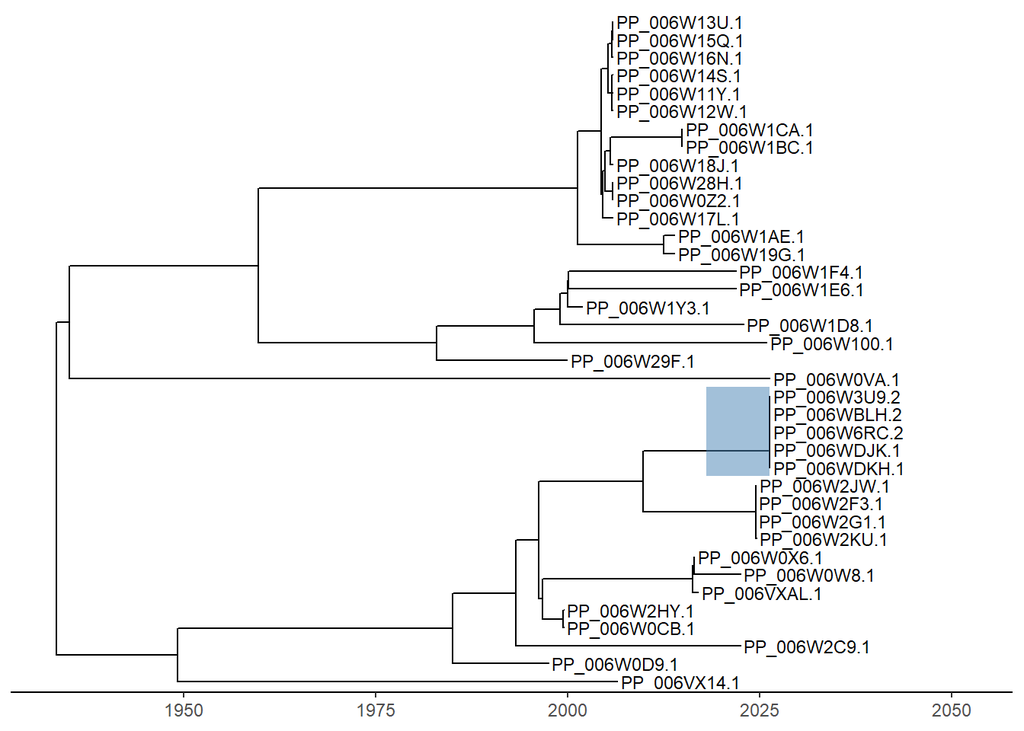

Figure 9: Time Calibrated Phylogenetic Tree for segment S

**tMRCA - segment S (lower and upper band)**

Table 5: Estimated time to Most Recent Common Ancestor for segment S, across various clock and coalescence models

Segment S: Outbreak Emergence Window Across Models

| Clock.Model | Coalescent.Prior | Stem.Date..Earliest.possible. | Crown.Date..Latest.possible. |
| --- | --- | --- | --- |
| Strict | None | 2019-09-16 | 2026-04-25 |
| Strict | Constant | 2019-10-03 | 2026-04-25 |
| Strict | Skyline | 2019-12-17 | 2026-04-25 |
| Uncorrelated Relaxed | None | 2009-10-18 | 2026-04-25 |
| Uncorrelated Relaxed | Constant | 2021-10-16 | 2026-04-25 |
| Uncorrelated Relaxed | Skyline | 2021-12-02 | 2026-04-25 |
| Correlated Relaxed | None | 2009-09-03 | 2026-04-25 |
| Correlated Relaxed | Constant | 2021-04-09 | 2026-04-25 |
| Correlated Relaxed | Skyline | 2021-06-04 | 2026-04-25 |

**Time calibrated phylogeny and tMRCA - segment M**

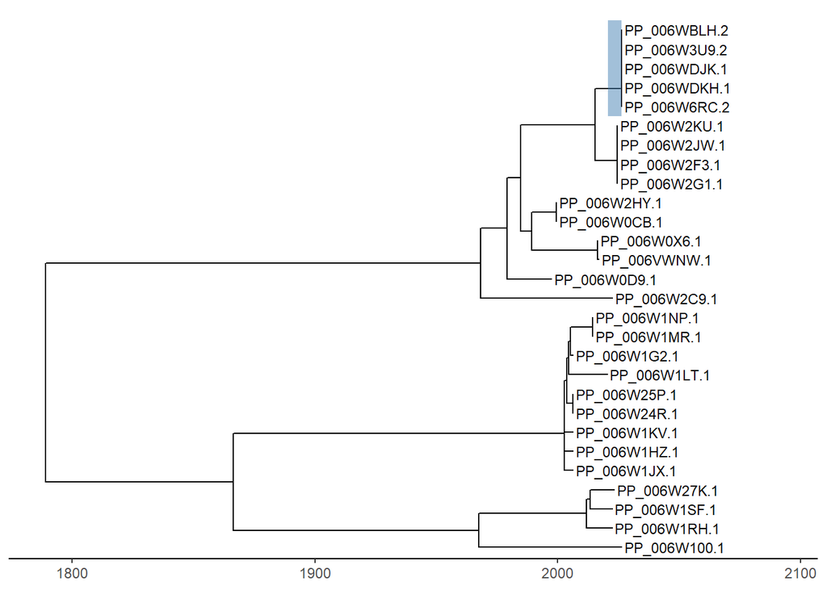

Figure 10: Time Calibrated Phylogenetic Tree for segment M

**tMRCA - segment M (lower and upper band)**

Table 6: Estimated time to Most Recent Common Ancestor for segment M, across various clock and coalescence models

Segment M: Outbreak Emergence Window Across Models

| Clock.Model | Coalescent.Prior | Stem.Date..Earliest.possible. | Crown.Date..Latest.possible. |
| --- | --- | --- | --- |
| Strict | None | 2010-06-28 | 2026-03-12 |
| Strict | Constant | 2011-04-21 | 2026-03-16 |
| Strict | Skyline | 2011-04-10 | 2026-03-16 |
| Uncorrelated Relaxed | None | 2015-04-09 | 2026-03-14 |
| Uncorrelated Relaxed | Constant | 2016-06-05 | 2026-03-20 |
| Uncorrelated Relaxed | Skyline | 2016-06-05 | 2026-03-20 |
| Correlated Relaxed | None | 2012-02-27 | 2026-03-10 |
| Correlated Relaxed | Constant | 2016-05-31 | 2026-03-25 |
| Correlated Relaxed | Skyline | 2016-06-02 | 2026-03-25 |